Class, the below is a standard set of instructions for each HW problems and subproblems.  
Students are allowed to work together on HW problems. Each student is required to write up their solutions individually for all problems in their respective submission. The goal is to advance your HW solutions beyond standard answers by helping each other.

Necessary Python libraries to install in order to run the notebook properly

```
pip install pandas numpy sklearn matplotlib seaborn hdbscan minisom kagglehub pytorch
```

# **1. Supervised Learning Techniques Comparison**

30 Points Total

In this problem evaluate and compare the performance of various supervised learning models: Logistic Regression, KNN, Naive Bayes, SVM, Decision Trees, Random Forest, Gradient Boosting, and Neural Networks.

First get the Heart dataset from Kaggle (https://www.kaggle.com/datasets/redwankarimsony/heart-disease-data/data) and explore. Load the dataset, examine its header, feature names, types of features.

### Dataset Info

Target Variable: `num`

- 0 indicates no heart disease
- 1 indicates the presence of heart disease
- 2 indicates the moderate heart disease
- 3 indicates severe heart disease
- 4 indicates critical heart disease

### Editable Variables for Notebook

```python
SEED = 42
TEST_SIZE = 0.20
CV_FOLDS = 5
```

## (a) Data Preprocessing:

- Loading Data: Load the dataset into a pandas DataFrame.
- Handling Missing Values: Check for missing values and handle them appropriately (e.g., using imputation).
- Feature Engineering: Create at least one new feature that could help improve model predictions.
- Scaling: Scale the continuous feature values using standardization or normalization.

```python
## Type solution here ##
import kagglehub
import pandas as pd
import numpy as np
from pathlib import Path
from sklearn.ensemble import RandomForestRegressor
from sklearn.preprocessing import StandardScaler

# turn off warnings to reduce output clutter
import warnings
warnings.filterwarnings("ignore")

class RandomForestImputer:

    def __init__(self, data: pd.DataFrame, random_state: int = 42):
        self.data = data.copy()
        self.random_state = random_state
        self.encoders = {}   # store label encoders for categorical columns

    def fit_transform(self):
        df_imputed = self.data.copy()

        for col in df_imputed.columns:

            if df_imputed[col].isna().sum() == 0:
                continue  # no missing values in this column

            print(f"Imputing column: {col}")

            # Split into observed and missing
            observed = df_imputed[df_imputed[col].notna()]
            missing = df_imputed[df_imputed[col].isna()]

            # Features = all other columns
            features = df_imputed.columns.drop(col)
            X_train = observed[features]
            X_test = missing[features]

            # Encode categoricals for ML
            # observed_enc = self._encode_categoricals(observed[features])
            # missing_enc = self._encode_categoricals(missing[features])

            # Target
            y = observed[col]

            model = RandomForestRegressor(n_estimators=100, random_state=self.random_state)

            # Train
            model.fit(X_train, y)

            # Predict missing values
            preds = model.predict(X_test)

            # Fill in missing values
            df_imputed.loc[df_imputed[col].isna(), col] = preds

        return df_imputed

# Download latest version
path = kagglehub.dataset_download("redwankarimsony/heart-disease-data")
file_name = "heart_disease_uci.csv"

df = pd.read_csv(Path(path, file_name))
df_encoded = pd.get_dummies(df)*1

imputer = RandomForestImputer(df_encoded, random_state=SEED)
df_imputed = imputer.fit_transform().astype(dtype=np.float64)

scaled_columns = ["age", "trestbps", "chol", "thalch", "oldpeak", "ca"]
target_variable = "num"

scaler = StandardScaler()
scaled_data = scaler.fit_transform(df_imputed.loc[:, scaled_columns])
df_scaled = df_imputed.copy()
df_scaled.loc[:, scaled_columns] = np.array(scaled_data, dtype=np.float64)

print("Path to dataset files:", path)
display(df.head())
display(df.info())

display(df_encoded.head())
display(df_encoded.info())

display(df_imputed.head())
display(df_imputed.info())

display(df_scaled.head())
display(df_scaled.info())
```

```
Imputing column: trestbps
Imputing column: chol
Imputing column: thalch
Imputing column: oldpeak
Imputing column: ca
Path to dataset files: C:\Users\zhatz\.cache\kagglehub\datasets\redwankarimsony\heart-disease-data\versions\6
```

|  | id | age | sex | dataset | cp | trestbps | chol | fbs | restecg | thalch | exang | oldpeak | slope | ca | thal | num |
| --- | --- | --- | --- | --- | --- | --- | --- | --- | --- | --- | --- | --- | --- | --- | --- | --- |
| 0 | 1 | 63 | Male | Cleveland | typical angina | 145.0 | 233.0 | True | lv hypertrophy | 150.0 | False | 2.3 | downsloping | 0.0 | fixed defect | 0 |
| 1 | 2 | 67 | Male | Cleveland | asymptomatic | 160.0 | 286.0 | False | lv hypertrophy | 108.0 | True | 1.5 | flat | 3.0 | normal | 2 |
| 2 | 3 | 67 | Male | Cleveland | asymptomatic | 120.0 | 229.0 | False | lv hypertrophy | 129.0 | True | 2.6 | flat | 2.0 | reversable defect | 1 |
| 3 | 4 | 37 | Male | Cleveland | non-anginal | 130.0 | 250.0 | False | normal | 187.0 | False | 3.5 | downsloping | 0.0 | normal | 0 |
| 4 | 5 | 41 | Female | Cleveland | atypical angina | 130.0 | 204.0 | False | lv hypertrophy | 172.0 | False | 1.4 | upsloping | 0.0 | normal | 0 |

```
<class 'pandas.core.frame.DataFrame'>
RangeIndex: 920 entries, 0 to 919
Data columns (total 16 columns):
 #   Column    Non-Null Count  Dtype
---  ------    --------------  -----
 0   id        920 non-null    int64
 1   age       920 non-null    int64
 2   sex       920 non-null    object
 3   dataset   920 non-null    object
 4   cp        920 non-null    object
 5   trestbps  861 non-null    float64
 6   chol      890 non-null    float64
 7   fbs       830 non-null    object
 8   restecg   918 non-null    object
 9   thalch    865 non-null    float64
 10  exang     865 non-null    object
 11  oldpeak   858 non-null    float64
 12  slope     611 non-null    object
 13  ca        309 non-null    float64
 14  thal      434 non-null    object
 15  num       920 non-null    int64
dtypes: float64(5), int64(3), object(8)
memory usage: 115.1+ KB
```

```
None
```

|  | id | age | trestbps | chol | thalch | oldpeak | ca | num | sex_Female | sex_Male | ... | restecg_normal | restecg_st-t abnormality | exang_False | exang_True | slope_downsloping | slope_flat | slope_upsloping | thal_fixed defect | thal_normal | thal_reversable defect |
| --- | --- | --- | --- | --- | --- | --- | --- | --- | --- | --- | --- | --- | --- | --- | --- | --- | --- | --- | --- | --- | --- |
| 0 | 1 | 63 | 145.0 | 233.0 | 150.0 | 2.3 | 0.0 | 0 | 0 | 1 | ... | 0 | 0 | 1 | 0 | 1 | 0 | 0 | 1 | 0 | 0 |
| 1 | 2 | 67 | 160.0 | 286.0 | 108.0 | 1.5 | 3.0 | 2 | 0 | 1 | ... | 0 | 0 | 0 | 1 | 0 | 1 | 0 | 0 | 1 | 0 |
| 2 | 3 | 67 | 120.0 | 229.0 | 129.0 | 2.6 | 2.0 | 1 | 0 | 1 | ... | 0 | 0 | 0 | 1 | 0 | 1 | 0 | 0 | 0 | 1 |
| 3 | 4 | 37 | 130.0 | 250.0 | 187.0 | 3.5 | 0.0 | 0 | 0 | 1 | ... | 1 | 0 | 1 | 0 | 1 | 0 | 0 | 0 | 1 | 0 |
| 4 | 5 | 41 | 130.0 | 204.0 | 172.0 | 1.4 | 0.0 | 0 | 1 | 0 | ... | 0 | 0 | 1 | 0 | 0 | 0 | 1 | 0 | 1 | 0 |

5 rows × 31 columns

```
<class 'pandas.core.frame.DataFrame'>
RangeIndex: 920 entries, 0 to 919
Data columns (total 31 columns):
 #   Column                    Non-Null Count  Dtype
---  ------                    --------------  -----
 0   id                        920 non-null    int64
 1   age                       920 non-null    int64
 2   trestbps                  861 non-null    float64
 3   chol                      890 non-null    float64
 4   thalch                    865 non-null    float64
 5   oldpeak                   858 non-null    float64
 6   ca                        309 non-null    float64
 7   num                       920 non-null    int64
 8   sex_Female                920 non-null    int32
 9   sex_Male                  920 non-null    int32
```

[output cut: 23 more lines]

```
None
```

|  | id | age | trestbps | chol | thalch | oldpeak | ca | num | sex_Female | sex_Male | ... | restecg_normal | restecg_st-t abnormality | exang_False | exang_True | slope_downsloping | slope_flat | slope_upsloping | thal_fixed defect | thal_normal | thal_reversable defect |
| --- | --- | --- | --- | --- | --- | --- | --- | --- | --- | --- | --- | --- | --- | --- | --- | --- | --- | --- | --- | --- | --- |
| 0 | 1.0 | 63.0 | 145.0 | 233.0 | 150.0 | 2.3 | 0.0 | 0.0 | 0.0 | 1.0 | ... | 0.0 | 0.0 | 1.0 | 0.0 | 1.0 | 0.0 | 0.0 | 1.0 | 0.0 | 0.0 |
| 1 | 2.0 | 67.0 | 160.0 | 286.0 | 108.0 | 1.5 | 3.0 | 2.0 | 0.0 | 1.0 | ... | 0.0 | 0.0 | 0.0 | 1.0 | 0.0 | 1.0 | 0.0 | 0.0 | 1.0 | 0.0 |
| 2 | 3.0 | 67.0 | 120.0 | 229.0 | 129.0 | 2.6 | 2.0 | 1.0 | 0.0 | 1.0 | ... | 0.0 | 0.0 | 0.0 | 1.0 | 0.0 | 1.0 | 0.0 | 0.0 | 0.0 | 1.0 |
| 3 | 4.0 | 37.0 | 130.0 | 250.0 | 187.0 | 3.5 | 0.0 | 0.0 | 0.0 | 1.0 | ... | 1.0 | 0.0 | 1.0 | 0.0 | 1.0 | 0.0 | 0.0 | 0.0 | 1.0 | 0.0 |
| 4 | 5.0 | 41.0 | 130.0 | 204.0 | 172.0 | 1.4 | 0.0 | 0.0 | 1.0 | 0.0 | ... | 0.0 | 0.0 | 1.0 | 0.0 | 0.0 | 0.0 | 1.0 | 0.0 | 1.0 | 0.0 |

5 rows × 31 columns

```
<class 'pandas.core.frame.DataFrame'>
RangeIndex: 920 entries, 0 to 919
Data columns (total 31 columns):
 #   Column                    Non-Null Count  Dtype
---  ------                    --------------  -----
 0   id                        920 non-null    float64
 1   age                       920 non-null    float64
 2   trestbps                  920 non-null    float64
 3   chol                      920 non-null    float64
 4   thalch                    920 non-null    float64
 5   oldpeak                   920 non-null    float64
 6   ca                        920 non-null    float64
 7   num                       920 non-null    float64
 8   sex_Female                920 non-null    float64
 9   sex_Male                  920 non-null    float64
```

[output cut: 23 more lines]

```
None
```

|  | id | age | trestbps | chol | thalch | oldpeak | ca | num | sex_Female | sex_Male | ... | restecg_normal | restecg_st-t abnormality | exang_False | exang_True | slope_downsloping | slope_flat | slope_upsloping | thal_fixed defect | thal_normal | thal_reversable defect |
| --- | --- | --- | --- | --- | --- | --- | --- | --- | --- | --- | --- | --- | --- | --- | --- | --- | --- | --- | --- | --- | --- |
| 0 | 1.0 | 1.007386 | 0.687557 | 0.297453 | 0.520935 | 1.345913 | -1.045935 | 0.0 | 0.0 | 1.0 | ... | 0.0 | 0.0 | 1.0 | 0.0 | 1.0 | 0.0 | 0.0 | 1.0 | 0.0 | 0.0 |
| 1 | 2.0 | 1.432034 | 1.499982 | 0.782847 | -1.138649 | 0.587023 | 3.391035 | 2.0 | 0.0 | 1.0 | ... | 0.0 | 0.0 | 0.0 | 1.0 | 0.0 | 1.0 | 0.0 | 0.0 | 1.0 | 0.0 |
| 2 | 3.0 | 1.432034 | -0.666486 | 0.260820 | -0.308857 | 1.630496 | 1.912045 | 1.0 | 0.0 | 1.0 | ... | 0.0 | 0.0 | 0.0 | 1.0 | 0.0 | 1.0 | 0.0 | 0.0 | 0.0 | 1.0 |
| 3 | 4.0 | -1.752828 | -0.124869 | 0.453146 | 1.982950 | 2.484248 | -1.045935 | 0.0 | 0.0 | 1.0 | ... | 1.0 | 0.0 | 1.0 | 0.0 | 1.0 | 0.0 | 0.0 | 0.0 | 1.0 | 0.0 |
| 4 | 5.0 | -1.328180 | -0.124869 | 0.031861 | 1.390242 | 0.492161 | -1.045935 | 0.0 | 1.0 | 0.0 | ... | 0.0 | 0.0 | 1.0 | 0.0 | 0.0 | 0.0 | 1.0 | 0.0 | 1.0 | 0.0 |

5 rows × 31 columns

```
<class 'pandas.core.frame.DataFrame'>
RangeIndex: 920 entries, 0 to 919
Data columns (total 31 columns):
 #   Column                    Non-Null Count  Dtype
---  ------                    --------------  -----
 0   id                        920 non-null    float64
 1   age                       920 non-null    float64
 2   trestbps                  920 non-null    float64
 3   chol                      920 non-null    float64
 4   thalch                    920 non-null    float64
 5   oldpeak                   920 non-null    float64
 6   ca                        920 non-null    float64
 7   num                       920 non-null    float64
 8   sex_Female                920 non-null    float64
 9   sex_Male                  920 non-null    float64
```

[output cut: 23 more lines]

```
None
```

# (b) Data Splitting:

- Train-Test Split: Split the data into training (80%) and testing (20%) sets.
- Cross-Validation Setup: Prepare for k-fold cross-validation (with k=5) to use during model tuning.

```python
## Type solution here ##
from sklearn.model_selection import train_test_split
from sklearn.model_selection import cross_val_score

X = df_scaled.loc[:, df_scaled.columns!=target_variable]
y = df_scaled.loc[:, df_scaled.columns==target_variable]

X_train, X_test, y_train, y_test = train_test_split(X, y, test_size=TEST_SIZE, random_state=SEED)
X_train
```

|  | id | age | trestbps | chol | thalch | oldpeak | ca | sex_Female | sex_Male | dataset_Cleveland | ... | restecg_normal | restecg_st-t abnormality | exang_False | exang_True | slope_downsloping | slope_flat | slope_upsloping | thal_fixed defect | thal_normal | thal_reversable defect |
| --- | --- | --- | --- | --- | --- | --- | --- | --- | --- | --- | --- | --- | --- | --- | --- | --- | --- | --- | --- | --- | --- |
| 880 | 881.0 | 0.901224 | 0.292875 | -0.279524 | -0.664482 | 2.009941 | 0.847172 | 0.0 | 1.0 | 0.0 | ... | 0.0 | 1.0 | 0.0 | 1.0 | 0.0 | 0.0 | 0.0 | 0.0 | 0.0 | 0.0 |
| 457 | 458.0 | 0.051927 | 0.958365 | 0.421739 | -0.585455 | -0.835896 | -0.794507 | 0.0 | 1.0 | 0.0 | ... | 1.0 | 0.0 | 1.0 | 0.0 | 0.0 | 0.0 | 0.0 | 0.0 | 0.0 | 0.0 |
| 797 | 798.0 | -0.266559 | -0.003260 | 1.268240 | -0.450187 | 0.110802 | 1.231709 | 0.0 | 1.0 | 0.0 | ... | 1.0 | 0.0 | 0.0 | 0.0 | 0.0 | 0.0 | 0.0 | 0.0 | 0.0 | 0.0 |
| 25 | 26.0 | -0.372721 | -0.666486 | 0.169236 | 0.837047 | 0.681884 | -1.045935 | 1.0 | 0.0 | 1.0 | ... | 1.0 | 0.0 | 1.0 | 0.0 | 0.0 | 1.0 | 0.0 | 0.0 | 1.0 | 0.0 |
| 84 | 85.0 | -0.160397 | -0.666486 | 1.140023 | 1.390242 | -0.646174 | -1.045935 | 0.0 | 1.0 | 1.0 | ... | 1.0 | 0.0 | 1.0 | 0.0 | 0.0 | 0.0 | 1.0 | 0.0 | 1.0 | 0.0 |
| ... | ... | ... | ... | ... | ... | ... | ... | ... | ... | ... | ... | ... | ... | ... | ... | ... | ... | ... | ... | ... | ... |
| 106 | 107.0 | 0.582737 | 0.416748 | -0.215415 | 0.995102 | -0.835896 | 0.433055 | 0.0 | 1.0 | 1.0 | ... | 1.0 | 0.0 | 0.0 | 1.0 | 0.0 | 0.0 | 1.0 | 0.0 | 0.0 | 1.0 |
| 270 | 271.0 | 0.795061 | 0.416748 | 0.059336 | 0.046768 | 0.966468 | 0.433055 | 0.0 | 1.0 | 1.0 | ... | 0.0 | 0.0 | 0.0 | 1.0 | 0.0 | 0.0 | 1.0 | 0.0 | 0.0 | 1.0 |
| 860 | 861.0 | 2.281330 | 1.499982 | 1.002648 | -0.980594 | 1.061329 | 1.261289 | 0.0 | 1.0 | 0.0 | ... | 1.0 | 0.0 | 0.0 | 1.0 | 1.0 | 0.0 | 0.0 | 0.0 | 0.0 | 1.0 |
| 435 | 436.0 | -0.054235 | 0.416748 | 0.141761 | 0.204824 | 1.061329 | -0.409970 | 1.0 | 0.0 | 0.0 | ... | 1.0 | 0.0 | 0.0 | 1.0 | 0.0 | 1.0 | 0.0 | 0.0 | 0.0 | 0.0 |
| 102 | 103.0 | 0.370413 | -0.233192 | 0.938539 | 0.876561 | -0.835896 | 0.433055 | 1.0 | 0.0 | 1.0 | ... | 0.0 | 0.0 | 1.0 | 0.0 | 0.0 | 0.0 | 1.0 | 0.0 | 1.0 | 0.0 |

736 rows × 30 columns

# (c) Model Building and Evaluation:

Model Implementation: Implement each of the following models:

- Logistic Regression
- K-Nearest Neighbors (KNN)
- Naive Bayes
- Support Vector Machine (SVM)
- Decision Tree
- Random Forest
- Gradient Boosting
- Neural Network (use PyTorch)

```python
## Type solution here ##
import numpy as np

# Logistic Regression
from sklearn.linear_model import LogisticRegression
logistic = LogisticRegression(solver="liblinear")
log_acc = cross_val_score(logistic, X_train.values, y_train.values.ravel(), scoring="accuracy")


# K-nearest Neighbors
from sklearn.neighbors import KNeighborsClassifier
knn = KNeighborsClassifier(n_neighbors=5, weights="uniform")
knn_acc = cross_val_score(knn, X_train.values, y_train.values.ravel(), scoring="accuracy")


# Naive Bayes
from sklearn.naive_bayes import GaussianNB
bayes = GaussianNB()
bayes_acc = cross_val_score(bayes, X_train.values, y_train.values.ravel(), scoring="accuracy")


# Support Vector Machines
from sklearn.svm import SVC
svm = SVC(C=1.0, kernel="rbf", degree=3, gamma=1.0)
svm_acc = cross_val_score(svm, X_train.values, y_train.values.ravel(), scoring="accuracy")


# Decision tree
from sklearn.tree import DecisionTreeClassifier
tree = DecisionTreeClassifier(criterion="gini", splitter="best")
tree_acc = cross_val_score(tree, X_train.values, y_train.values.ravel(), scoring="accuracy")


# Random forest
from sklearn.ensemble import RandomForestClassifier
forest = RandomForestClassifier(n_estimators=100, criterion="gini")
forest_acc = cross_val_score(forest, X_train.values, y_train.values.ravel(), scoring="accuracy")


# gradient boosting
from sklearn.ensemble import GradientBoostingClassifier
gradient = GradientBoostingClassifier(loss="log_loss", learning_rate=0.1, n_estimators=100, subsample=1.0, criterion="friedman_mse")
grad_acc = cross_val_score(gradient, X_train.values, y_train.values.ravel(), scoring="accuracy")


# neural network with pytorch
import torch
import torch.nn as nn
import torch.optim as optim
from sklearn.metrics import accuracy_score
from torch.utils.data import TensorDataset, DataLoader

# Convert to PyTorch tensors
X_train_nn = torch.tensor(X_train.values, dtype=torch.float32)
X_test_nn  = torch.tensor(X_test.values, dtype=torch.float32)
y_train_nn = torch.tensor(y_train.values, dtype=torch.long)  # class labels must be long
y_test_nn  = torch.tensor(y_test.values, dtype=torch.long)

# Build dataloaders
train_dataset = TensorDataset(X_train_nn, y_train_nn)
test_dataset  = TensorDataset(X_test_nn, y_test_nn)

train_loader = DataLoader(train_dataset, batch_size=16, shuffle=True)
test_loader  = DataLoader(test_dataset, batch_size=16, shuffle=False)

class SimpleNN(nn.Module):
    def __init__(self, input_size, hidden_size, num_classes):
        super(SimpleNN, self).__init__()
        self.fc1 = nn.Linear(input_size, hidden_size)
        self.relu = nn.ReLU()
        self.fc2 = nn.Linear(hidden_size, num_classes)

    def forward(self, x):
        out = self.fc1(x)
        out = self.relu(out)
        out = self.fc2(out)  # raw scores (logits)
        return out

# Initialize model
nn_hyperparam = {
    "hidden_size": 16,
    "criterion": nn.CrossEntropyLoss(),
    "lr": 0.01,
    "epochs": 50
}

print("Neural Network Training Loop")
print("-"*35)
num_classes = len(torch.unique(y_train_nn))
model = SimpleNN(input_size=X_train.shape[1], hidden_size=nn_hyperparam["hidden_size"], num_classes=num_classes)
criterion = nn_hyperparam["criterion"]   # suitable for multi-class classification
optimizer = optim.Adam(model.parameters(), lr=nn_hyperparam["lr"])
num_epochs = nn_hyperparam["epochs"]

for epoch in range(num_epochs):
    model.train()
    for X_batch, y_batch in train_loader:
        # Forward pass
        outputs = model(X_batch)
        loss = criterion(outputs, y_batch.squeeze())

        # Backward pass
        optimizer.zero_grad()
        loss.backward()
        optimizer.step()

    if (epoch+1) % 10 == 0:
        print(f"Epoch [{epoch+1}/{num_epochs}], Loss: {loss.item():.4f}")

model.eval()
correct, total = 0, 0
with torch.no_grad():
    for X_batch, y_batch in train_loader:
        outputs = model(X_batch)
        _, predicted = torch.max(outputs.data, 1)
        total += y_batch.size(0)
        correct += (predicted == y_batch.squeeze()).sum().item()


print("")
print("Cross Validation Avg. Model Accuracy Scores")
print("-"*35)
print(f"{'Logistic Regression Accuracy:':<36}{np.mean(log_acc)*100:.2f}%")
print(f"{'KNN Classifier Accuracy:':<36}{np.mean(knn_acc)*100:.2f}%")
print(f"{'Naive Bayes Accuracy:':<36}{np.mean(bayes_acc)*100:.2f}%")
print(f"{'Support Vector Machines Accuracy:':<36}{np.mean(svm_acc)*100:.2f}%")
print(f"{'Decision Tree Classifier Accuracy:':<36}{np.mean(tree_acc)*100:.2f}%")
print(f"{'Random Forest Accuracy:':<36}{np.mean(forest_acc)*100:.2f}%")
print(f"{'Gradient Boosting Accuracy:':<36}{np.mean(grad_acc)*100:.2f}%")
print(f"{'Neural Network Accuracy:':<36}{correct / total*100:.2f}%")
```

```
Neural Network Training Loop
-----------------------------------
Epoch [10/50], Loss: 0.7389
Epoch [20/50], Loss: 1.7483
Epoch [30/50], Loss: 0.8940
Epoch [40/50], Loss: 0.3897
Epoch [50/50], Loss: 0.5728

Cross Validation Avg. Model Accuracy Scores
-----------------------------------
Logistic Regression Accuracy:       63.32%
KNN Classifier Accuracy:            60.19%
Naive Bayes Accuracy:               48.50%
Support Vector Machines Accuracy:   45.65%
Decision Tree Classifier Accuracy:  61.00%
Random Forest Accuracy:             69.84%
Gradient Boosting Accuracy:         67.25%
Neural Network Accuracy:            66.30%
```

# (d) Hyperparameter Tuning:

Use grid search with cross-validation to find the best hyperparameters for each model.

```python
from sklearn.model_selection import GridSearchCV
from sklearn.metrics import precision_score, recall_score, f1_score, accuracy_score, roc_auc_score, roc_curve
```

### Logistic Regression

```python
## Type solution here ##

logistic = LogisticRegression()

param_grid_logreg = {
    "penalty": ["l1", "l2"],              # type of regularization
    "C": [0.01, 0.1, 1, 10],              # inverse of regularization strength
    "solver": ["liblinear", "saga"],      # both support l1 and l2
    "max_iter": [100, 500]
}

# Create GridSearchCV object
grid_search_logistic = GridSearchCV(estimator=logistic, param_grid=param_grid_logreg, cv=CV_FOLDS, scoring='accuracy')

# Fit the GridSearchCV to the data
grid_search_logistic.fit(X_train, y_train.squeeze())

# Get the best model from grid search
best_logreg = grid_search_logistic.best_estimator_

# Predictions
y_pred = best_logreg.predict(X_test)
y_prob = best_logreg.predict_proba(X_test)  # needed for ROC/AUC

# Metrics
accuracy_logreg = accuracy_score(y_test, y_pred)
precision_logreg = precision_score(y_test, y_pred, average="weighted")  # use 'macro'/'weighted' if multiclass
recall_logreg = recall_score(y_test, y_pred, average="weighted")
f1_logreg = f1_score(y_test, y_pred, average="weighted")
roc_auc_logreg = roc_auc_score(y_test, y_prob, multi_class="ovr")

print("Best Logistic Regression Hyperparameters:", grid_search_logistic.best_params_)
print(f"Accuracy:  {accuracy_logreg:.4f}")
print(f"Precision: {precision_logreg:.4f}")
print(f"Recall:    {recall_logreg:.4f}")
print(f"F1 Score:  {f1_logreg:.4f}")
print(f"ROC AUC:   {roc_auc_logreg:.4f}")
```

```
Best Logistic Regression Hyperparameters: {'C': 1, 'max_iter': 100, 'penalty': 'l1', 'solver': 'liblinear'}
Accuracy:  0.5543
Precision: 0.4769
Recall:    0.5543
F1 Score:  0.5051
ROC AUC:   0.8554
```

### K-Nearest Neighbors (KNN)

```python
## Type solution here ##

knn = KNeighborsClassifier()

param_grid_knn = {
    "n_neighbors": [3, 5, 7, 11],         # typical small values
    "weights": ["uniform", "distance"],   # weighting scheme
    "metric": ["euclidean", "manhattan"]  # distance metrics
}

# Create GridSearchCV object
grid_search_knn = GridSearchCV(estimator=knn, param_grid=param_grid_knn, cv=CV_FOLDS, scoring='accuracy')

# Fit the GridSearchCV to the data
grid_search_knn.fit(X_train, y_train.squeeze())

# Get the best model from grid search
best_knn = grid_search_knn.best_estimator_

# Predictions
y_pred = best_knn.predict(X_test)
y_prob = best_knn.predict_proba(X_test)  # needed for ROC/AUC

# Metrics
accuracy_knn = accuracy_score(y_test, y_pred)
precision_knn = precision_score(y_test, y_pred, average="weighted")  # use 'macro'/'weighted' if multiclass
recall_knn = recall_score(y_test, y_pred, average="weighted")
f1_knn = f1_score(y_test, y_pred, average="weighted")
roc_auc_knn = roc_auc_score(y_test, y_prob, multi_class="ovr")

print("Best K-Nearest Neighbors Hyperparameters:", grid_search_knn.best_params_)
print(f"Accuracy:  {accuracy_knn:.4f}")
print(f"Precision: {precision_knn:.4f}")
print(f"Recall:    {recall_knn:.4f}")
print(f"F1 Score:  {f1_knn:.4f}")
print(f"ROC AUC:   {roc_auc_knn:.4f}")
```

```
Best K-Nearest Neighbors Hyperparameters: {'metric': 'manhattan', 'n_neighbors': 7, 'weights': 'distance'}
Accuracy:  0.5924
Precision: 0.5527
Recall:    0.5924
F1 Score:  0.5568
ROC AUC:   0.7406
```

### Naive Bayes

```python
## Type solution here ##

bayes = GaussianNB()

param_grid_nb = {
    "var_smoothing": [1e-9, 1e-8, 1e-7, 1e-6, 1e-5, 1e-4]
}


# Create GridSearchCV object
grid_search_nb = GridSearchCV(estimator=bayes, param_grid=param_grid_nb, cv=CV_FOLDS, scoring='accuracy')
# Fit the GridSearchCV to the data
grid_search_nb.fit(X_train, y_train.squeeze())

# Get the best model from grid search
best_nb = grid_search_nb.best_estimator_

# Predictions
y_pred = best_nb.predict(X_test)
y_prob = best_nb.predict_proba(X_test)  # needed for ROC/AUC

# Metrics
accuracy_nb = accuracy_score(y_test, y_pred)
precision_nb = precision_score(y_test, y_pred, average="weighted")  # use 'macro'/'weighted' if multiclass
recall_nb = recall_score(y_test, y_pred, average="weighted")
f1_nb = f1_score(y_test, y_pred, average="weighted")
roc_auc_nb = roc_auc_score(y_test, y_prob, multi_class="ovr")

print("Best Naive Bayes Hyperparameters:", grid_search_nb.best_params_)
print(f"Accuracy:  {accuracy_nb:.4f}")
print(f"Precision: {precision_nb:.4f}")
print(f"Recall:    {recall_nb:.4f}")
print(f"F1 Score:  {f1_nb:.4f}")
print(f"ROC AUC:   {roc_auc_nb:.4f}")
```

```
Best Naive Bayes Hyperparameters: {'var_smoothing': 1e-05}
Accuracy:  0.5761
Precision: 0.5296
Recall:    0.5761
F1 Score:  0.5365
ROC AUC:   0.8381
```

### SVC

```python
## Type solution here ##


# Define the estimator
svm = SVC(probability=True)

# Define the parameter grid
param_grid_svc = {
    'C': [0.1, 1],
    'kernel': ['linear', 'rbf'],
    'gamma': [0.001, 0.01]
}

# Create GridSearchCV object
grid_search_svc = GridSearchCV(estimator=svm, param_grid=param_grid_svc, cv=CV_FOLDS, scoring='accuracy')

# Fit the GridSearchCV to the data
grid_search_svc.fit(X_train, y_train.squeeze())

# Get the best model from grid search
best_svc = grid_search_svc.best_estimator_

# Predictions
y_pred = best_svc.predict(X_test)
y_prob = best_svc.predict_proba(X_test)  # needed for ROC/AUC

# Metrics
accuracy_svc = accuracy_score(y_test, y_pred)
precision_svc = precision_score(y_test, y_pred, average="weighted")  # use 'macro'/'weighted' if multiclass
recall_svc = recall_score(y_test, y_pred, average="weighted")
f1_svc = f1_score(y_test, y_pred, average="weighted")
roc_auc_svc = roc_auc_score(y_test, y_prob, multi_class="ovr")

print("Best SVC Hyperparameters:", grid_search_svc.best_params_)
print(f"Accuracy:  {accuracy_svc:.4f}")
print(f"Precision: {precision_svc:.4f}")
print(f"Recall:    {recall_svc:.4f}")
print(f"F1 Score:  {f1_svc:.4f}")
print(f"ROC AUC:   {roc_auc_svc:.4f}")
```

```
Best SVC Hyperparameters: {'C': 0.1, 'gamma': 0.001, 'kernel': 'linear'}
Accuracy:  0.6141
Precision: 0.5522
Recall:    0.6141
F1 Score:  0.5690
ROC AUC:   0.8656
```

### Decision Tree

```python
## Type solution here ##

tree = DecisionTreeClassifier()

param_grid_dt = {
    "criterion": ["gini", "entropy"],     # impurity measure
    "max_depth": [None, 5, 10, 20],       # limit tree growth
    "min_samples_split": [2, 5, 10],      # min samples to split a node
    "min_samples_leaf": [1, 2, 4]         # min samples per leaf
}

# Create GridSearchCV object
grid_search_dt = GridSearchCV(estimator=tree, param_grid=param_grid_dt, cv=CV_FOLDS, scoring='accuracy')

# Fit the GridSearchCV to the data
grid_search_dt.fit(X_train, y_train.squeeze())

# Get the best model from grid search
best_dt = grid_search_dt.best_estimator_

# Predictions
y_pred = best_dt.predict(X_test)
y_prob = best_dt.predict_proba(X_test)  # needed for ROC/AUC

# Metrics
accuracy_dt = accuracy_score(y_test, y_pred)
precision_dt = precision_score(y_test, y_pred, average="weighted")  # use 'macro'/'weighted' if multiclass
recall_dt = recall_score(y_test, y_pred, average="weighted")
f1_dt = f1_score(y_test, y_pred, average="weighted")
roc_auc_dt = roc_auc_score(y_test, y_prob, multi_class="ovr")

print("Best Decision Tree Hyperparameters:", grid_search_dt.best_params_)
print(f"Accuracy:  {accuracy_dt:.4f}")
print(f"Precision: {precision_dt:.4f}")
print(f"Recall:    {recall_dt:.4f}")
print(f"F1 Score:  {f1_dt:.4f}")
print(f"ROC AUC:   {roc_auc_dt:.4f}")
```

```
Best Decision Tree Hyperparameters: {'criterion': 'gini', 'max_depth': 5, 'min_samples_leaf': 2, 'min_samples_split': 10}
Accuracy:  0.6630
Precision: 0.6162
Recall:    0.6630
F1 Score:  0.6343
ROC AUC:   0.8649
```

### Random Forest

```python
## Type solution here ##

forest = RandomForestClassifier()

param_grid_rf = {
    "n_estimators": [100, 200],           # # of trees
    "criterion": ["gini", "entropy"],
    "max_depth": [None, 10, 20],
    "min_samples_split": [2, 5],
    "min_samples_leaf": [1, 2],
    "max_features": ["sqrt", "log2"]      # feature subset strategy
}


# Create GridSearchCV object
grid_search_rf = GridSearchCV(estimator=forest, param_grid=param_grid_rf, cv=CV_FOLDS, scoring='accuracy')

# Fit the GridSearchCV to the data
grid_search_rf.fit(X_train, y_train.squeeze())

# Get the best model from grid search
best_rf = grid_search_rf.best_estimator_

# Predictions
y_pred = best_rf.predict(X_test)
y_prob = best_rf.predict_proba(X_test)  # needed for ROC/AUC

# Metrics
accuracy_rf = accuracy_score(y_test, y_pred)
precision_rf = precision_score(y_test, y_pred, average="weighted")  # use 'macro'/'weighted' if multiclass
recall_rf = recall_score(y_test, y_pred, average="weighted")
f1_rf = f1_score(y_test, y_pred, average="weighted")
roc_auc_rf = roc_auc_score(y_test, y_prob, multi_class="ovr")

print("Best Random Forest Hyperparameters:", grid_search_rf.best_params_)
print(f"Accuracy:  {accuracy_rf:.4f}")
print(f"Precision: {precision_rf:.4f}")
print(f"Recall:    {recall_rf:.4f}")
print(f"F1 Score:  {f1_rf:.4f}")
print(f"ROC AUC:   {roc_auc_rf:.4f}")
```

```
Best Random Forest Hyperparameters: {'criterion': 'entropy', 'max_depth': 20, 'max_features': 'sqrt', 'min_samples_leaf': 2, 'min_samples_split': 2, 'n_estimators': 200}
Accuracy:  0.6739
Precision: 0.6349
Recall:    0.6739
F1 Score:  0.6487
ROC AUC:   0.8975
```

### Gradient Boosting

```python
## Type solution here ##

gradient = GradientBoostingClassifier()

param_grid_gb = {
    "n_estimators": [100],           # boosting stages
    "learning_rate": [0.01, 0.1, 0.2],    # step size
    "max_depth": [3],                  # depth of individual trees
    "min_samples_split": [2, 5],
    "min_samples_leaf": [1, 2],
    "subsample": [0.8, 1.0]               # row sampling
}

# Create GridSearchCV object
grid_search_gb = GridSearchCV(estimator=gradient, param_grid=param_grid_gb, cv=CV_FOLDS, scoring='accuracy')

# Fit the GridSearchCV to the data
grid_search_gb.fit(X_train, y_train.squeeze())

# Get the best model from grid search
best_gb = grid_search_gb.best_estimator_

# Predictions
y_pred = best_gb.predict(X_test)
y_prob = best_gb.predict_proba(X_test)  # needed for ROC/AUC

# Metrics
accuracy_gb = accuracy_score(y_test, y_pred)
precision_gb = precision_score(y_test, y_pred, average="weighted")  # use 'macro'/'weighted' if multiclass
recall_gb = recall_score(y_test, y_pred, average="weighted")
f1_gb = f1_score(y_test, y_pred, average="weighted")
roc_auc_gb = roc_auc_score(y_test, y_prob, multi_class="ovr")

print("Best Gradient Boosting Hyperparameters:", grid_search_gb.best_params_)
print(f"Accuracy:  {accuracy_gb:.4f}")
print(f"Precision: {precision_gb:.4f}")
print(f"Recall:    {recall_gb:.4f}")
print(f"F1 Score:  {f1_gb:.4f}")
print(f"ROC AUC:   {roc_auc_gb:.4f}")
```

```
Best Gradient Boosting Hyperparameters: {'learning_rate': 0.01, 'max_depth': 3, 'min_samples_leaf': 1, 'min_samples_split': 5, 'n_estimators': 100, 'subsample': 0.8}
Accuracy:  0.6793
Precision: 0.6389
Recall:    0.6793
F1 Score:  0.6366
ROC AUC:   0.8813
```

### Neural Network

```python
import torch
import torch.nn as nn
import torch.optim as optim
import itertools
import numpy as np

# Example neural net
class SimpleNN(nn.Module):
    def __init__(self, input_size, hidden_size, num_classes):
        super(SimpleNN, self).__init__()
        self.fc1 = nn.Linear(input_size, hidden_size)
        self.relu = nn.ReLU()
        self.fc2 = nn.Linear(hidden_size, num_classes)

    def forward(self, x):
        out = self.fc1(x)
        out = self.relu(out)
        out = self.fc2(out)
        return out


# Define hyperparameter grid
param_grid_nn = {
    "hidden_size": [16, 32, 64],
    "lr": [0.1, 0.01, 0.001],
    "epochs": [30, 50],
    "criterion": [nn.CrossEntropyLoss()]  # usually fixed
}

# Generate all param combinations
param_combinations = list(itertools.product(
    param_grid_nn["hidden_size"],
    param_grid_nn["lr"],
    param_grid_nn["epochs"],
    param_grid_nn["criterion"]
))

print("Neural Network Hyperparameter Search")
print("-"*40)

best_acc = 0.0
best_params = None

num_classes = len(torch.unique(y_train_nn))

for hidden_size, lr, epochs, criterion in param_combinations:
    # print(f"\nTraining with hidden_size={hidden_size}, lr={lr}, epochs={epochs}")

    # Initialize new model + optimizer for each combo
    model = SimpleNN(input_size=X_train.shape[1], hidden_size=hidden_size, num_classes=num_classes)
    optimizer = optim.Adam(model.parameters(), lr=lr)

    # Training loop
    for epoch in range(epochs):
        model.train()
        for X_batch, y_batch in train_loader:
            outputs = model(X_batch)
            loss = criterion(outputs, y_batch.squeeze())

            optimizer.zero_grad()
            loss.backward()
            optimizer.step()

    # Evaluation on test set
    model.eval()
    all_preds, all_probs, all_targets = [], [], []
    with torch.no_grad():
        for X_batch, y_batch in test_loader:
            outputs = model(X_batch)
            probs = torch.softmax(outputs, dim=1)  # probabilities
            _, predicted = torch.max(probs, 1)

            all_preds.extend(predicted.cpu().numpy())
            all_probs.extend(probs.cpu().numpy())
            all_targets.extend(y_batch.cpu().numpy())

    # Convert to numpy arrays
    y_pred = np.array(all_preds)
    y_prob = np.array(all_probs)
    y_true = np.array(all_targets)

    acc = accuracy_score(y_true, y_pred) * 100
    # print(f"Accuracy: {acc:.2f}%")

    # Save best model and metrics
    if acc > best_acc:
        best_acc = acc
        best_params = {"hidden_size": hidden_size, "lr": lr, "epochs": epochs}

        # Metrics
        accuracy_nn = accuracy_score(y_true, y_pred)
        precision_nn = precision_score(y_true, y_pred, average="weighted")
        recall_nn = recall_score(y_true, y_pred, average="weighted")
        f1_nn = f1_score(y_true, y_pred, average="weighted")

        # ROC AUC: binary vs multiclass handling
        if num_classes == 2:
            roc_auc_nn = roc_auc_score(y_true, y_prob[:, 1])
        else:
            roc_auc_nn = roc_auc_score(y_true, y_prob, multi_class="ovr")

print("Best Neural Network Hyperparameters:", best_params)
print(f"Accuracy:  {accuracy_nn:.4f}")
print(f"Precision: {precision_nn:.4f}")
print(f"Recall:    {recall_nn:.4f}")
print(f"F1 Score:  {f1_nn:.4f}")
print(f"ROC AUC:   {roc_auc_nn:.4f}")
```

```
Neural Network Hyperparameter Search
----------------------------------------
Best Neural Network Hyperparameters: {'hidden_size': 16, 'lr': 0.01, 'epochs': 50}
Accuracy:  0.6087
Precision: 0.5626
Recall:    0.6087
F1 Score:  0.5789
ROC AUC:   0.8521
```

# (e) Model Evaluation:

Evaluate each model using the test set with the following metrics:

- Accuracy
- Precision, Recall, and F1-Score
- ROC Curve and AUC

```python
## Type solution here ##
import pandas as pd
best_metrics = {
    "Logistic Regression": {"Accuracy": accuracy_logreg, "Precision": precision_logreg, "Recall": recall_logreg, "F1 Score": f1_logreg, "ROC/AUC": roc_auc_logreg},
    "K-Nearest Neighbors": {"Accuracy": accuracy_knn, "Precision": precision_knn, "Recall": recall_knn, "F1 Score": f1_knn, "ROC/AUC": roc_auc_knn},
    "Naive Bayes": {"Accuracy": accuracy_nb, "Precision": precision_nb, "Recall": recall_nb, "F1 Score": f1_nb, "ROC/AUC": roc_auc_nb},
    "SVC": {"Accuracy": accuracy_svc, "Precision": precision_svc, "Recall": recall_svc, "F1 Score": f1_svc, "ROC/AUC": roc_auc_svc},
    "Decision Tree": {"Accuracy": accuracy_dt, "Precision": precision_dt, "Recall": recall_dt, "F1 Score": f1_dt, "ROC/AUC": roc_auc_dt},
    "Random Forest": {"Accuracy": accuracy_rf, "Precision": precision_rf, "Recall": recall_rf, "F1 Score": f1_rf, "ROC/AUC": roc_auc_rf},
    "Gradient Boosting": {"Accuracy": accuracy_gb, "Precision": precision_gb, "Recall": recall_gb, "F1 Score": f1_gb, "ROC/AUC": roc_auc_gb},
    "Neural Network": {"Accuracy": accuracy_nn, "Precision": precision_nn, "Recall": recall_nn, "F1 Score": f1_nn, "ROC/AUC": roc_auc_nn},
}
df_results = pd.DataFrame.from_dict(best_metrics).T.rename_axis('Model')
df_results
```

| Model | Accuracy | Precision | Recall | F1 Score | ROC/AUC |
| --- | --- | --- | --- | --- | --- |
| Logistic Regression | 0.554348 | 0.476884 | 0.554348 | 0.505102 | 0.855361 |
| K-Nearest Neighbors | 0.592391 | 0.552719 | 0.592391 | 0.556762 | 0.740614 |
| Naive Bayes | 0.576087 | 0.529634 | 0.576087 | 0.536475 | 0.838127 |
| SVC | 0.614130 | 0.552218 | 0.614130 | 0.568967 | 0.865621 |
| Decision Tree | 0.663043 | 0.616224 | 0.663043 | 0.634285 | 0.864910 |
| Random Forest | 0.673913 | 0.634884 | 0.673913 | 0.648721 | 0.897468 |
| Gradient Boosting | 0.679348 | 0.638934 | 0.679348 | 0.636557 | 0.881322 |
| Neural Network | 0.608696 | 0.562619 | 0.608696 | 0.578922 | 0.852148 |

# (f) Analysis:

# **2. Unsupervised Learning Methods**

70 Points Total

Apply various unsupervised learning algorithms to real-world data, exploring data preprocessing, model evaluation, and analysis of the resulting clusters. This assignment will cover K-Means Clustering, Hierarchical Clustering, Generative Models (GMM, VAEs, GANs), Anomaly Detection, Self-Organizing Maps (SOMs), and DBSCAN.

# (a) Data Exploration & Preprocessing:

- Load the "Mall Customer Segmentation Data" dataset from Kaggle, choose one of the following:
  - https://www.kaggle.com/datasets/vjchoudhary7/customer-segmentation-tutorial-in-python
  - https://www.kaggle.com/datasets/datazng/shopping-mall-customer-data-segmentation-analysis/data
- Explore the dataset to understand its structure, feature types, and distributions.
- Preprocess:
  - Handle any missing values, if present.
  - Normalize or standardize numerical features (e.g., Annual Income, Spending Score) to ensure proper scaling for clustering algorithms.
  - Convert categorical features (e.g., Gender) to numerical representations using one-hot encoding.
- Deliverable: Provide a summary of the preprocessing steps you applied, with justifications for each step.

### Data Loading & Inspection:

The dataset was imported from Kaggle and inspected to understand structure, data types, and missing values.

### Feature Separation:

Numerical (Age, Annual Income, Spending Score) and categorical (Gender) columns were identified for appropriate preprocessing.

### Encoding:

Gender was one-hot encoded to convert categorical values into numeric form.

### Scaling:

Numerical features were standardized using StandardScaler to ensure equal contribution across features.

### Cleaning:

The Customer ID column was removed since it has no analytical value.

```python
## Type solution here ##
import kagglehub
import seaborn as sns
import pandas as pd
from pathlib import Path

from sklearn.preprocessing import StandardScaler

# Download latest version
path = kagglehub.dataset_download("datazng/shopping-mall-customer-data-segmentation-analysis")
file_name = "Shopping Mall Customer Segmentation Data .csv"

df = pd.read_csv(Path(path, file_name))

numerical_cols = ['Age', 'Annual Income', 'Spending Score']
categorical_cols = ["Gender"]

scaler = StandardScaler()

df_cleaned = pd.get_dummies(df, columns=categorical_cols)*1
df_cleaned[numerical_cols] = scaler.fit_transform(df_cleaned[numerical_cols])

X = df_cleaned.loc[:, df_cleaned.columns!="Customer ID"]

print("Path to dataset files:", path)
print("")

print("Original Data Set Information")
display(df.head())
display(df.describe())
display(df.info())

print("")
print("Cleaned Data Set Information")
display(df_cleaned.head())
display(df_cleaned.describe())
display(df_cleaned.info())
```

```
Path to dataset files: C:\Users\zhatz\.cache\kagglehub\datasets\datazng\shopping-mall-customer-data-segmentation-analysis\versions\1

Original Data Set Information
```

|  | Customer ID | Age | Gender | Annual Income | Spending Score |
| --- | --- | --- | --- | --- | --- |
| 0 | d410ea53-6661-42a9-ad3a-f554b05fd2a7 | 30 | Male | 151479 | 89 |
| 1 | 1770b26f-493f-46b6-837f-4237fb5a314e | 58 | Female | 185088 | 95 |
| 2 | e81aa8eb-1767-4b77-87ce-1620dc732c5e | 62 | Female | 70912 | 76 |
| 3 | 9795712a-ad19-47bf-8886-4f997d6046e3 | 23 | Male | 55460 | 57 |
| 4 | 64139426-2226-4cd6-bf09-91bce4b4db5e | 24 | Male | 153752 | 76 |

|  | Age | Annual Income | Spending Score |
| --- | --- | --- | --- |
| count | 15079.000000 | 15079.000000 | 15079.000000 |
| mean | 54.191591 | 109742.880562 | 50.591617 |
| std | 21.119207 | 52249.425866 | 28.726977 |
| min | 18.000000 | 20022.000000 | 1.000000 |
| 25% | 36.000000 | 64141.000000 | 26.000000 |
| 50% | 54.000000 | 109190.000000 | 51.000000 |
| 75% | 72.000000 | 155008.000000 | 75.000000 |
| max | 90.000000 | 199974.000000 | 100.000000 |

```
<class 'pandas.core.frame.DataFrame'>
RangeIndex: 15079 entries, 0 to 15078
Data columns (total 5 columns):
 #   Column          Non-Null Count  Dtype
---  ------          --------------  -----
 0   Customer ID     15079 non-null  object
 1   Age             15079 non-null  int64
 2   Gender          15079 non-null  object
 3   Annual Income   15079 non-null  int64
 4   Spending Score  15079 non-null  int64
dtypes: int64(3), object(2)
memory usage: 589.1+ KB
```

```
None
```

```
Cleaned Data Set Information
```

|  | Customer ID | Age | Annual Income | Spending Score | Gender_Female | Gender_Male |
| --- | --- | --- | --- | --- | --- | --- |
| 0 | d410ea53-6661-42a9-ad3a-f554b05fd2a7 | -1.145516 | 0.798813 | 1.337059 | 0 | 1 |
| 1 | 1770b26f-493f-46b6-837f-4237fb5a314e | 0.180335 | 1.442076 | 1.545929 | 1 | 0 |
| 2 | e81aa8eb-1767-4b77-87ce-1620dc732c5e | 0.369742 | -0.743208 | 0.884507 | 1 | 0 |
| 3 | 9795712a-ad19-47bf-8886-4f997d6046e3 | -1.476979 | -1.038953 | 0.223086 | 0 | 1 |
| 4 | 64139426-2226-4cd6-bf09-91bce4b4db5e | -1.429627 | 0.842317 | 0.884507 | 0 | 1 |

|  | Age | Annual Income | Spending Score | Gender_Female | Gender_Male |
| --- | --- | --- | --- | --- | --- |
| count | 1.507900e+04 | 1.507900e+04 | 1.507900e+04 | 15079.000000 | 15079.000000 |
| mean | -3.204251e-17 | -1.168609e-16 | -7.633658e-17 | 0.496319 | 0.503681 |
| std | 1.000033e+00 | 1.000033e+00 | 1.000033e+00 | 0.500003 | 0.500003 |
| min | -1.713738e+00 | -1.717222e+00 | -1.726365e+00 | 0.000000 | 0.000000 |
| 25% | -8.614052e-01 | -8.728018e-01 | -8.560745e-01 | 0.000000 | 0.000000 |
| 50% | -9.072183e-03 | -1.058191e-02 | 1.421646e-02 | 0.000000 | 1.000000 |
| 75% | 8.432608e-01 | 8.663563e-01 | 8.496958e-01 | 1.000000 | 1.000000 |
| max | 1.695594e+00 | 1.726988e+00 | 1.719987e+00 | 1.000000 | 1.000000 |

```
<class 'pandas.core.frame.DataFrame'>
RangeIndex: 15079 entries, 0 to 15078
Data columns (total 6 columns):
 #   Column          Non-Null Count  Dtype
---  ------          --------------  -----
 0   Customer ID     15079 non-null  object
 1   Age             15079 non-null  float64
 2   Annual Income   15079 non-null  float64
 3   Spending Score  15079 non-null  float64
 4   Gender_Female   15079 non-null  int32
 5   Gender_Male     15079 non-null  int32
dtypes: float64(3), int32(2), object(1)
memory usage: 589.1+ KB
```

```
None
```

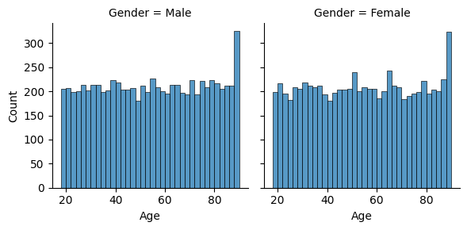

```python
g = sns.FacetGrid(df, col="Gender")
g.map_dataframe(sns.histplot, x="Age", binwidth=2)
```

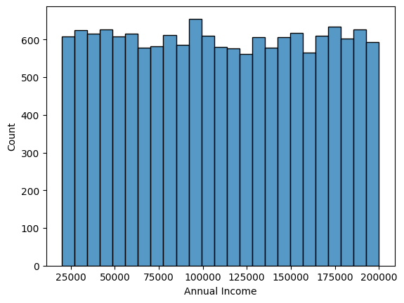

```python
sns.histplot(data=df, x="Annual Income")
```

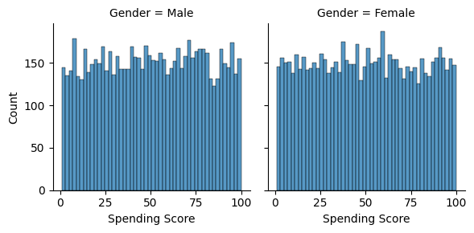

```python
g = sns.FacetGrid(df, col="Gender")
g.map_dataframe(sns.histplot, x="Spending Score", binwidth=2)
```

# (b) K-Means Clustering:

- Apply K-Means clustering to the dataset. Use the Elbow Method and Silhouette Score to determine the optimal number of clusters, 𝑘.
- Visualize the clusters in a 2D plot using Principal Component Analysis (PCA) to reduce the data to two dimensions.
- Analysis:
  - Interpret the clusters: What do they represent in terms of customer behavior (e.g., high spenders, low-income)?
  - How does changing 𝑘 affect the clustering results?
- Deliverable: Include plots showing the Elbow Method and Silhouette Score. Visualize the clusters and provide an analysis of what each cluster represents.

### K-Means Clustering Interpretation

Cluster Interpretation: The 13 clusters represent distinct customer segments based on age, annual income, and spending score. Each cluster reflects different patterns of customer behavior, such as:

- High-income, high-spending customers — likely premium shoppers or loyal clients.
- High-income, low-spending customers — financially capable but less engaged.
- Low-income, high-spending customers — possibly younger or impulsive buyers.
- Low-income, low-spending customers — budget-conscious or infrequent shoppers.
- Middle-income, moderate-spending customers — representing the average or balanced group.
- Clusters also vary by age, showing distinctions between younger, middle-aged, and older customer groups with similar spending patterns.

```python
## Type solution here ##
from sklearn.cluster import KMeans
import numpy as np
from sklearn.metrics import silhouette_score

inertias, silhouettes = [], []

K_RANGE = np.arange(2, 40)

for k in K_RANGE:
    # TODO: fit KMeans; record inertia and silhouette score
    km = KMeans(n_clusters=k, random_state=SEED)
    labels = km.fit_predict(X)
    inertias.append(km.inertia_)
    silhouettes.append(silhouette_score(X, labels))
print('Computed metrics for K:', K_RANGE)
```

```
Computed metrics for K: [ 2  3  4  5  6  7  8  9 10 11 12 13 14 15 16 17 18 19 20 21 22 23 24 25
 26 27 28 29 30 31 32 33 34 35 36 37 38 39]
```

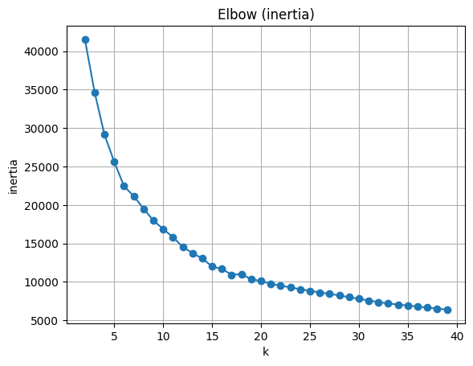

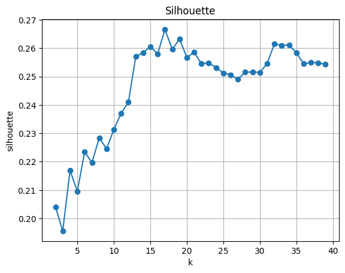

```python
# Plots for Elbow (Inertia) and Silhouette
import matplotlib.pyplot as plt

plt.figure()
plt.plot(K_RANGE, inertias, marker="o")
plt.title("Elbow (inertia)")
plt.xlabel("k")
plt.ylabel("inertia")
plt.grid(True)
plt.show()

plt.figure()
plt.plot(K_RANGE, silhouettes, marker="o")
plt.title("Silhouette")
plt.xlabel("k")
plt.ylabel("silhouette")
plt.grid(True)
plt.show()
```

```python
# Optimal cluster is around 13 because inertia has substantially decreased and has diminishing returns after 13 while silhouette is still increasing
optimal_cluster = 13

kmeans = KMeans(n_clusters=optimal_cluster, random_state=SEED)
labels = kmeans.fit_predict(X)
df_clusters = df_cleaned.copy()
df_clusters["Cluster"] = labels
sizes = df_clusters['Cluster'].value_counts().sort_index()
display(sizes.to_frame('count').T)
```

| Cluster | 0 | 1 | 2 | 3 | 4 | 5 | 6 | 7 | 8 | 9 | 10 | 11 | 12 |
| --- | --- | --- | --- | --- | --- | --- | --- | --- | --- | --- | --- | --- | --- |
| count | 1227 | 1124 | 1139 | 1218 | 1117 | 1145 | 1141 | 1109 | 1119 | 1166 | 1136 | 1233 | 1205 |

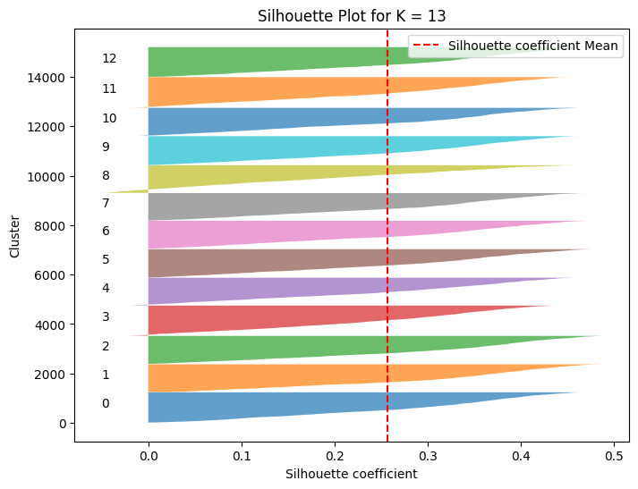

```python
# Silhouette plot for chosen K
import numpy as np, matplotlib.pyplot as plt
from sklearn.metrics import silhouette_samples
# TODO: compute silhouette_samples for labels and plot distribution per cluster
sil = silhouette_samples(X, labels)

y_lower = 10
plt.figure(figsize=(8, 6))

for i in range(optimal_cluster):
    # Get silhouette values for cluster i
    cluster_sil_values = sil[labels == i]
    cluster_sil_values.sort()

    # Compute where to place them on y-axis
    size_cluster_i = cluster_sil_values.shape[0]
    y_upper = y_lower + size_cluster_i

    # Fill silhouette bars
    plt.fill_betweenx(np.arange(y_lower, y_upper),
                      0, cluster_sil_values,
                      alpha=0.7)

    # Label cluster number in the middle
    plt.text(-0.05, y_lower + 0.5 * size_cluster_i, str(i))

    y_lower = y_upper + 10  # add gap between clusters

# Vertical line for average silhouette score
plt.axvline(np.mean(sil), color="red", linestyle="--", label="Silhouette coefficient Mean")
plt.legend()
plt.xlabel("Silhouette coefficient")
plt.ylabel("Cluster")
plt.title("Silhouette Plot for K = {}".format(optimal_cluster))
plt.show()
```

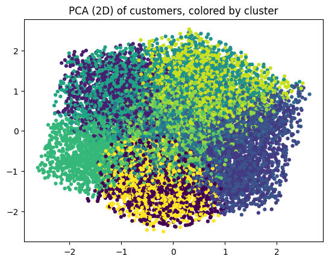

```python
# Optional: PCA (2D) projection for visualization
from sklearn.decomposition import PCA
import matplotlib.pyplot as plt

pca = PCA(n_components=2, random_state=SEED)
Z = pca.fit_transform(X)
plt.figure(); plt.scatter(Z[:,0], Z[:,1], c=labels, s=12)
plt.title('PCA (2D) of customers, colored by cluster'); plt.show()
```

# (c) Hierarchical Clustering:

- Apply Agglomerative Hierarchical Clustering to the dataset. Use different linkage methods (e.g., single, complete, average) and plot dendrograms for each.
- Analysis:
  - Compare the clustering results with those obtained from K-Means. How do the clusters change with different linkage methods?
- Deliverable: Provide dendrogram plots and an analysis comparing hierarchical clustering with K-Means clustering.

### Comparison with K-Means:

Agglomerative clustering produced broadly similar groupings to K-Means, identifying segments that differ in age, income, and spending behavior. However, unlike K-Means, which forms spherical and evenly sized clusters, agglomerative clustering can capture hierarchical relationships and non-spherical patterns among customers. This often results in clusters of unequal sizes and more natural groupings that reflect gradual transitions between customer types.

Effect of Different Linkage Methods:

- Single Linkage:
  - Forms clusters based on the minimum distance between points. It tends to create long, chain-like clusters and is sensitive to outliers.
- Complete Linkage:
  - Uses the maximum distance between points, producing compact and well-separated clusters similar in shape to K-Means results.
- Average Linkage:
  - Balances between single and complete linkage, generating moderately compact clusters and often yielding the most interpretable structure.

```python
## Type solution here ##
from sklearn.cluster import AgglomerativeClustering

df_clusters_agglo = df_cleaned.copy()

agglo = AgglomerativeClustering(n_clusters=optimal_cluster, linkage="single")
agglo_labels = agglo.fit_predict(X)
df_clusters_agglo["Cluster Single"] = agglo_labels

agglo = AgglomerativeClustering(n_clusters=optimal_cluster, linkage="complete")
agglo_labels = agglo.fit_predict(X)
df_clusters_agglo["Cluster Complete"] = agglo_labels

agglo = AgglomerativeClustering(n_clusters=optimal_cluster, linkage="average")
agglo_labels = agglo.fit_predict(X)
df_clusters_agglo["Cluster Average"] = agglo_labels

df_clusters_agglo
```

|  | Customer ID | Age | Annual Income | Spending Score | Gender_Female | Gender_Male | Cluster Single | Cluster Complete | Cluster Average |
| --- | --- | --- | --- | --- | --- | --- | --- | --- | --- |
| 0 | d410ea53-6661-42a9-ad3a-f554b05fd2a7 | -1.145516 | 0.798813 | 1.337059 | 0 | 1 | 2 | 1 | 9 |
| 1 | 1770b26f-493f-46b6-837f-4237fb5a314e | 0.180335 | 1.442076 | 1.545929 | 1 | 0 | 0 | 12 | 8 |
| 2 | e81aa8eb-1767-4b77-87ce-1620dc732c5e | 0.369742 | -0.743208 | 0.884507 | 1 | 0 | 0 | 6 | 3 |
| 3 | 9795712a-ad19-47bf-8886-4f997d6046e3 | -1.476979 | -1.038953 | 0.223086 | 0 | 1 | 2 | 0 | 12 |
| 4 | 64139426-2226-4cd6-bf09-91bce4b4db5e | -1.429627 | 0.842317 | 0.884507 | 0 | 1 | 2 | 1 | 9 |
| ... | ... | ... | ... | ... | ... | ... | ... | ... | ... |
| 15074 | a0504768-a85f-4930-ac24-55bc8e4fec9e | -1.192868 | -0.230056 | -0.716828 | 1 | 0 | 0 | 0 | 7 |
| 15075 | a08c4e0e-d1fe-48e7-9366-aab11ae409cd | -1.524331 | -0.696335 | 0.814884 | 0 | 1 | 2 | 8 | 0 |
| 15076 | 0e87c25a-268c-401a-8ba1-7111dcde6f1a | -1.713738 | 0.049650 | -0.090218 | 1 | 0 | 0 | 9 | 1 |
| 15077 | 5f388cbe-3373-4e16-b743-38f508f2249f | -1.334923 | -0.295341 | -1.587119 | 1 | 0 | 0 | 0 | 7 |
| 15078 | b8b8f561-ebca-4401-8afe-544c906554ba | -1.666386 | -0.606685 | -1.691554 | 0 | 1 | 2 | 0 | 6 |

15079 rows × 9 columns

```python
import numpy as np
from matplotlib import pyplot as plt
from scipy.cluster.hierarchy import dendrogram


def plot_dendrogram(model, **kwargs):
    # Create linkage matrix and then plot the dendrogram

    # create the counts of samples under each node
    counts = np.zeros(model.children_.shape[0])
    n_samples = len(model.labels_)
    for i, merge in enumerate(model.children_):
        current_count = 0
        for child_idx in merge:
            if child_idx < n_samples:
                current_count += 1  # leaf node
            else:
                current_count += counts[child_idx - n_samples]
        counts[i] = current_count

    linkage_matrix = np.column_stack(
        [model.children_, model.distances_, counts]
    ).astype(float)

    # Plot the corresponding dendrogram
    dendrogram(linkage_matrix, **kwargs)
```

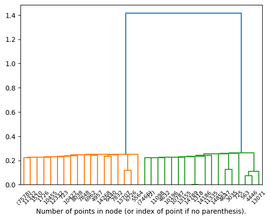

```python
# Fit model with distances
model = AgglomerativeClustering(distance_threshold=0, n_clusters=None, linkage="single")
model = model.fit(X)

plot_dendrogram(model, truncate_mode="level", p=optimal_cluster)
plt.xlabel("Number of points in node (or index of point if no parenthesis).")
plt.show()
```

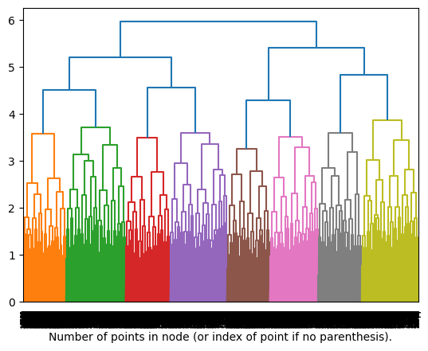

```python
# Fit model with distances
model = AgglomerativeClustering(distance_threshold=0, n_clusters=None, linkage="complete")
model = model.fit(X)

plot_dendrogram(model, truncate_mode="level", p=optimal_cluster)
plt.xlabel("Number of points in node (or index of point if no parenthesis).")
plt.show()
```

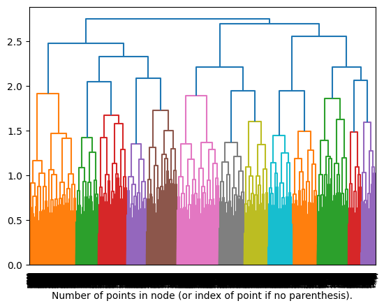

```python
# Fit model with distances
model = AgglomerativeClustering(distance_threshold=0, n_clusters=None, linkage="average")
model = model.fit(X)

plot_dendrogram(model, truncate_mode="level", p=optimal_cluster)
plt.xlabel("Number of points in node (or index of point if no parenthesis).")
plt.show()
```

# (d) Generative Models:

- Gaussian Mixture Model (GMM):
  - Apply GMM to cluster the customers. Compare the results with those from K-Means and hierarchical clustering.
  - Visualize the clusters in a 2D plot using PCA.
- Variational Autoencoder (VAE) (Optional for advanced students):
  - Train a VAE using the dataset. Visualize the latent space to see how customer features are organized.
- Generative Adversarial Networks (GANs) (Optional for advanced students):
  - Use a GAN to generate new customer profiles based on the existing dataset. How realistic are these generated profiles? Deliverable: Include visualizations of clusters for GMM and latent space representations for VAE (if applicable). Discuss the differences between these generative models and other clustering methods.

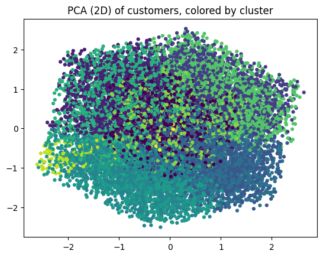

```python
## Type solution here ##

from sklearn.mixture import GaussianMixture

gmm = GaussianMixture(n_components=optimal_cluster)
gmm_labels = gmm.fit_predict(X)

pca = PCA(n_components=2, random_state=SEED)
Z = pca.fit_transform(X)
plt.figure(); plt.scatter(Z[:,0], Z[:,1], c=gmm_labels, s=12)
plt.title('PCA (2D) of customers, colored by cluster'); plt.show()
```

# (e) Anomaly Detection:

- Implement an anomaly detection method (e.g., Isolation Forest) to identify outliers in the dataset. Visualize these outliers.
- Analysis:
  - What characteristics make these customers outliers?
  - How might a business use this information?
- Deliverable: Provide plots showing the identified anomalies and an analysis of what these anomalies represent in the context of customer behavior.

Outlier Characteristics: Customers identified as outliers by the Isolation Forest model typically have unusual combinations of features such as:

- Extremely high or low annual income compared to the majority.
- Very high spending scores relative to income (potential impulsive buyers).
- Very low spending scores despite high income (inactive or disengaged customers).
- Uncommon age spending patterns, such as older customers with unusually high spending activity.
- These deviations indicate that these customers behave differently from typical spending and income trends in the dataset.

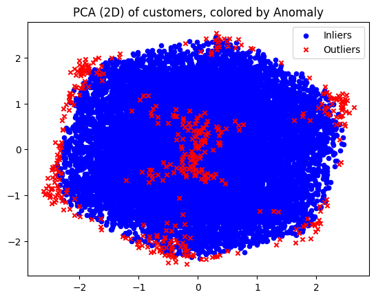

```python
## Type solution here ##

from sklearn.ensemble import IsolationForest

# Fit Isolation Forest
isoforest = IsolationForest(
    contamination=0.03, random_state=SEED
)  # contamination ~ % of expected outliers
isoforest.fit(X)

# Anomaly scores (the lower, the more abnormal)
anomaly_score = isoforest.decision_function(X)

# Predictions (-1 = outlier, 1 = inlier)
outliers = isoforest.predict(X)

# --- Plotting (works well if X has 2 features, otherwise use PCA) ---
if X.shape[1] == 2:
    plt.figure(figsize=(8, 6))
    plt.scatter(
        X[outliers == 1, 0], X[outliers == 1, 1], c="blue", label="Inliers", s=20
    )
    plt.scatter(
        X[outliers == -1, 0],
        X[outliers == -1, 1],
        c="red",
        label="Outliers",
        s=20,
        marker="x",
    )
    plt.title("Isolation Forest Outlier Detection")
    plt.legend()
    plt.show()
else:
    pca = PCA(n_components=2, random_state=SEED)
    Z = pca.fit_transform(X)
    plt.figure()
    plt.scatter(Z[outliers == 1, 0], Z[outliers == 1, 1],
                c='blue', label='Inliers', s=20)
    plt.scatter(Z[outliers == -1, 0], Z[outliers == -1, 1],
                c='red', label='Outliers', s=20, marker='x')
    plt.title("PCA (2D) of customers, colored by Anomaly")
    plt.legend()
    plt.show()
```

```python
df_outliers = df.copy()
df_outliers["Anomaly"] = outliers
df_outliers["Anomaly Score"] = anomaly_score
print("Inlier Data Set Information")
display(df_outliers.loc[df_outliers["Anomaly"] == 1, :].describe())
print("Outlier Data Set Information")
display(df_outliers.loc[df_outliers["Anomaly"] == -1, :].describe())
```

```
Inlier Data Set Information
```

|  | Age | Annual Income | Spending Score | Anomaly | Anomaly Score |
| --- | --- | --- | --- | --- | --- |
| count | 14626.000000 | 14626.000000 | 14626.000000 | 14626.0 | 14626.000000 |
| mean | 54.503077 | 109697.102010 | 50.644605 | 1.0 | 0.067091 |
| std | 20.658576 | 51418.823312 | 28.199830 | 0.0 | 0.028728 |
| min | 18.000000 | 20022.000000 | 1.000000 | 1.0 | 0.000011 |
| 25% | 37.000000 | 65180.000000 | 27.000000 | 1.0 | 0.045829 |
| 50% | 55.000000 | 109187.000000 | 51.000000 | 1.0 | 0.069185 |
| 75% | 72.000000 | 154069.250000 | 75.000000 | 1.0 | 0.090318 |
| max | 90.000000 | 199974.000000 | 100.000000 | 1.0 | 0.132769 |

```
Outlier Data Set Information
```

|  | Age | Annual Income | Spending Score | Anomaly | Anomaly Score |
| --- | --- | --- | --- | --- | --- |
| count | 453.000000 | 453.000000 | 453.000000 | 453.0 | 453.000000 |
| mean | 44.134658 | 111220.931567 | 48.880795 | -1.0 | -0.012599 |
| std | 31.067183 | 74295.918791 | 42.367586 | 0.0 | 0.010516 |
| min | 18.000000 | 20101.000000 | 1.000000 | -1.0 | -0.052940 |
| 25% | 19.000000 | 32602.000000 | 7.000000 | -1.0 | -0.019053 |
| 50% | 23.000000 | 118293.000000 | 31.000000 | -1.0 | -0.009247 |
| 75% | 85.000000 | 189858.000000 | 96.000000 | -1.0 | -0.004306 |
| max | 90.000000 | 199963.000000 | 100.000000 | -1.0 | -0.000006 |

# (f) Self-Organizing Maps (SOMs):

- Train a SOM on the dataset to visualize customer segments in a 2D map.
- Analysis:
  - Interpret the map: What patterns or clusters can you identify?
  - Compare these patterns with those from K-Means and hierarchical clustering.
- Deliverable: Include the SOM visualization and discuss how it relates to other clustering results.

Map Interpretation:

Comparison with K-Means and Hierarchical Clustering:

- Like K-Means, SOM identifies groups based on feature similarity, but it provides a spatial representation showing how clusters relate to one another.
- Compared to hierarchical clustering, SOM offers a more continuous and topological view, revealing gradual transitions between customer segments instead of rigid divisions.
- SOM often highlights subtle patterns missed by both methods, such as small but meaningful variations within larger K-Means clusters.

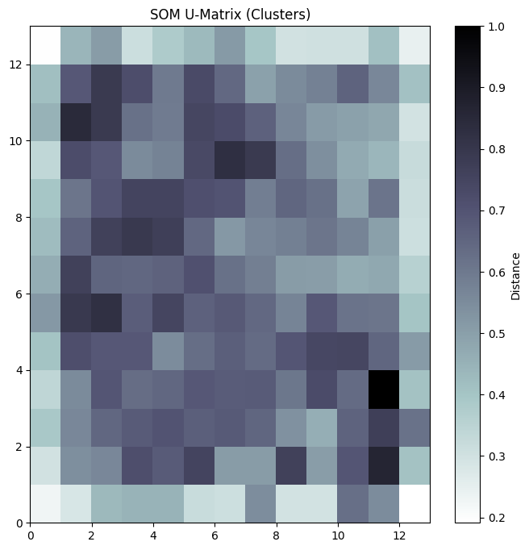

```python
## Type solution here ##
import numpy as np
import matplotlib.pyplot as plt
from minisom import MiniSom

# Example: assume X is your scaled dataset (numpy array)
som_shape = (optimal_cluster, optimal_cluster)  # 20x20 grid of neurons
som = MiniSom(x=som_shape[0], y=som_shape[1], input_len=X.shape[1], sigma=1.0, learning_rate=0.5)

som.random_weights_init(X.values)
som.train_random(X.values, num_iteration=1000)  # train with 1000 iterations

plt.figure(figsize=(8, 8))
plt.pcolor(som.distance_map().T, cmap='bone_r')  # U-matrix
plt.colorbar(label='Distance')
plt.title("SOM U-Matrix (Clusters)")
plt.show()
```

# (g) DBSCAN (Density-Based Spatial Clustering of Applications with Noise):

- Apply DBSCAN to the dataset to identify clusters based on density.
- Analysis:
  - How many clusters does DBSCAN identify, and what are the characteristics of these clusters?
  - How does DBSCAN handle outliers compared to K-Means and hierarchical clustering?
- Deliverable: Provide the clustering results from DBSCAN, including a plot, and analyze the differences compared to other methods.

### DBSCAN Analysis

- The clusters are large and balanced (7,595 vs 7,484 points).
- DBSCAN essentially found two dense regions in the data, with all points assigned.

### Outlier handling comparison

- DBSCAN: no outliers detected, but in principle it can explicitly mark low-density points as noise.
- K-Means: every point forced into a cluster, outliers just get absorbed.
- Hierarchical: same as K-Means, every point gets placed somewhere, sometimes creating tiny “singleton” clusters that look like outliers but aren’t treated as such.

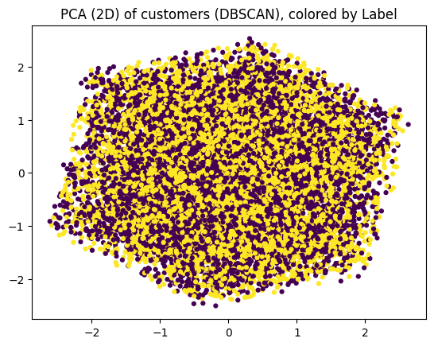

```python
## Type solution here ##
from sklearn.cluster import DBSCAN

scan = DBSCAN()
scan_labels = scan.fit_predict(X)

pca = PCA(n_components=2, random_state=SEED)
Z = pca.fit_transform(X)
plt.figure(); plt.scatter(Z[:,0], Z[:,1], c=scan_labels, s=12)
plt.title('PCA (2D) of customers (DBSCAN), colored by Label'); plt.show()
```

# (h) Model Evaluation & Analysis:

- Compare all the clustering algorithms (K-Means, Hierarchical Clustering, GMM, SOMs, DBSCAN). Discuss their strengths, weaknesses, and when one might be more appropriate to use over the others.
- For the generative models (GMM, VAEs, GANs), discuss how they differ from traditional clustering algorithms and what unique insights they can provide.
- Deliverable: A summary table comparing the results and key characteristics of each algorithm (e.g., cluster quality, handling of outliers, interpretability).

### Comparison of Clustering Algorithms

- K-Means: Fast, easy, assumes spherical clusters, sensitive to outliers.
- Hierarchical: Captures hierarchy, no need for k, but slow and sensitive to noise.
- GMM: Soft clustering, models ellipses, probabilistic/generative, slower than K-Means.
- SOM: Good for visualization and topology, harder to interpret, needs tuning.
- DBSCAN: Finds irregular shapes, handles noise/outliers, struggles with varying density.
- Isolation Forest: Not clustering, detects outliers directly, scalable.

### Comparison Table

| Algorithm | Cluster Shape | Handles Noise | Outliers | Soft vs Hard | Scalability | Interpretability | Unique Insights |
| --- | --- | --- | --- | --- | --- | --- | --- |
| **K-Means** | Spherical, equal size | Poor | Sensitive | Hard | High | Easy | Simple partitions |
| **Hierarchical (Single)** | Arbitrary, chaining effect | Poor | Sensitive | Hard | Low (expensive) | Medium | Nested structure |
| **Hierarchical (Complete/Average)** | Arbitrary | Poor | Sensitive | Hard | Low | Medium | Different linkage views |
| **GMM** | Elliptical, overlapping | Moderate | Some sensitivity | **Soft** | Medium | Medium | Probabilistic, generative |
| **SOM** | Flexible | Limited | Sensitive | Hard | Medium | Low-Medium | Visualization, topology preservation |
| **DBSCAN** | Arbitrary | Excellent | Excellent | Hard | Medium | Medium | Finds irregular clusters |
| **Isolation Forest** | N/A (not clusters) | Excellent | **Explicit detection** | N/A | High | Medium | Outlier detection only |

```python
## Type solution here ##
summary_dict = {
    "KMeans": df_clusters["Cluster"].value_counts().sort_index().to_dict(),
    "Agglomerative Single": df_clusters_agglo["Cluster Single"].value_counts().sort_index().to_dict(),
    "Agglomerative Complete": df_clusters_agglo["Cluster Complete"].value_counts().sort_index().to_dict(),
    "Agglomerative Average": df_clusters_agglo["Cluster Average"].value_counts().sort_index().to_dict(),
    "GMM": pd.Series(gmm_labels).value_counts().sort_index().to_dict(),
    "Isolation Forest": pd.Series(outliers).value_counts().sort_index().to_dict(),
    "DBSCAN": pd.Series(scan_labels).value_counts().sort_index().to_dict()
}
df_summary = pd.DataFrame.from_dict(summary_dict, orient='index').fillna(0).astype(int)
df_summary.columns = [f'Cluster {i}' for i in df_summary.columns]
df_summary.T
```

[output not shown]

# (i) Optional Extra Credit:

- Implement a Hierarchical Density-Based Spatial Clustering (HDBSCAN) on the dataset and compare it with DBSCAN and other clustering methods.
- Apply Autoencoders for anomaly detection and compare its effectiveness to Isolation Forest.

### HDBSCAN

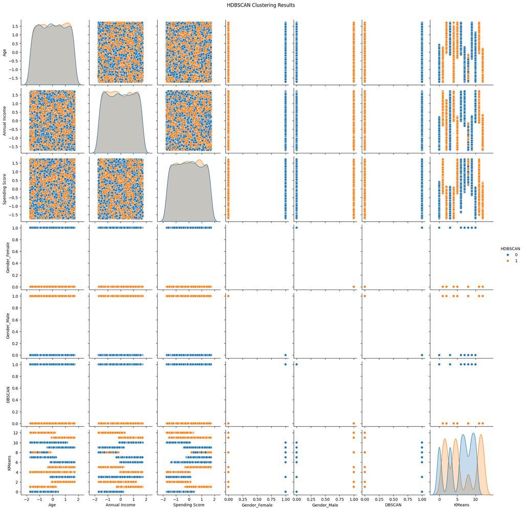

```
HDBSCAN clusters: 2
DBSCAN clusters: 2
KMeans clusters: 13
```

```python
import hdbscan
from sklearn.cluster import DBSCAN, KMeans
import matplotlib.pyplot as plt
import seaborn as sns

# HDBSCAN
hdbscan_model = hdbscan.HDBSCAN(min_cluster_size=5)
hdbscan_labels = hdbscan_model.fit_predict(X)

# DBSCAN for comparison
dbscan_model = DBSCAN(eps=0.5, min_samples=5)
dbscan_labels = dbscan_model.fit_predict(X)

# K-Means for comparison
kmeans = KMeans(n_clusters=optimal_cluster, random_state=SEED)
kmeans_labels = kmeans.fit_predict(X)

# Add results for easy visualization
X_plot = X.copy()
X_plot["HDBSCAN"] = hdbscan_labels
X_plot["DBSCAN"] = dbscan_labels
X_plot["KMeans"] = kmeans_labels

# Visualize HDBSCAN results
sns.pairplot(X_plot, hue="HDBSCAN", palette="tab10")
plt.suptitle("HDBSCAN Clustering Results", y=1.02)
plt.show()

# Compare number of clusters
print("HDBSCAN clusters:", len(set(hdbscan_labels)) - (1 if -1 in hdbscan_labels else 0))
print("DBSCAN clusters:", len(set(dbscan_labels)) - (1 if -1 in dbscan_labels else 0))
print("KMeans clusters:", len(set(kmeans_labels)))
```

### Autoencoder

```
Epoch [10/50], Loss: 0.866598
Epoch [20/50], Loss: 0.856891
Epoch [30/50], Loss: 0.849104
Epoch [40/50], Loss: 0.842265
Epoch [50/50], Loss: 0.835481
Autoencoder detected 754 anomalies out of 15079
Isolation Forest detected 754 anomalies out of 15079
```

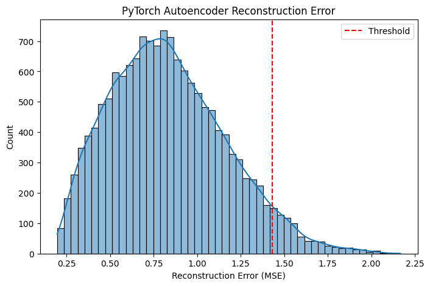

```python
import torch
import torch.nn as nn
import torch.optim as optim
from sklearn.ensemble import IsolationForest
import matplotlib.pyplot as plt
import seaborn as sns
import numpy as np

# Prepare data
X_tensor = torch.tensor(X.values, dtype=torch.float32)

# Split into train/test
train_size = int(0.8 * len(X_tensor))
X_train = X_tensor[:train_size]
X_test = X_tensor[train_size:]

# Define Autoencoder model
class Autoencoder(nn.Module):
    def __init__(self, input_dim):
        super(Autoencoder, self).__init__()
        self.encoder = nn.Sequential(
            nn.Linear(input_dim, 8),
            nn.ReLU(),
            nn.Linear(8, 3),
            nn.ReLU()
        )
        self.decoder = nn.Sequential(
            nn.Linear(3, 8),
            nn.ReLU(),
            nn.Linear(8, input_dim)
        )

    def forward(self, x):
        encoded = self.encoder(x)
        decoded = self.decoder(encoded)
        return decoded

# Initialize model, loss, and optimizer
input_dim = X.shape[1]
model = Autoencoder(input_dim)
criterion = nn.MSELoss()
optimizer = optim.Adam(model.parameters(), lr=0.001)

# Training loop
epochs = 50
for epoch in range(epochs):
    model.train()
    optimizer.zero_grad()
    outputs = model(X_train)
    loss = criterion(outputs, X_train)
    loss.backward()
    optimizer.step()

    if (epoch+1) % 10 == 0:
        print(f"Epoch [{epoch+1}/{epochs}], Loss: {loss.item():.6f}")

# Compute reconstruction errors
model.eval()
with torch.no_grad():
    reconstructed = model(X_tensor)
mse = torch.mean((X_tensor - reconstructed) ** 2, dim=1).numpy()

# Identify anomalies
threshold = np.percentile(mse, 95)
anomalies = mse > threshold
print(f"Autoencoder detected {np.sum(anomalies)} anomalies out of {len(X)}")

# Compare with Isolation Forest
iso = IsolationForest(contamination=0.05, random_state=SEED)
iso_labels = iso.fit_predict(X)
iso_anomalies = iso_labels == -1
print(f"Isolation Forest detected {np.sum(iso_anomalies)} anomalies out of {len(X)}")

# Plot reconstruction error distribution
plt.figure(figsize=(8,5))
sns.histplot(mse, bins=50, kde=True)
plt.axvline(threshold, color='red', linestyle='--', label='Threshold')
plt.title("PyTorch Autoencoder Reconstruction Error")
plt.xlabel("Reconstruction Error (MSE)")
plt.legend()
plt.show()
```

# References

[1] Christopher M. Bishop. Neural Networks for Pattern Recognition. Oxford University Press, 1995.  
[2] Christopher Bishop. Pattern Recognition and Machine Learning. Springer, 2006. isbn: 0387310738.  
[3] Barry J. Shepherd C. Wayne Brown. Graphics File Formats: Reference and Guide. Manning Publications, 1995. isbn: 1884777007.  
[4] Thomas H. Cormen et al. Introduction to Algorithms. 3rd. MIT Press, 2009. isbn: 780262033848.  
[5] W. R. Dillon and M. Goldstein. Multivariate Analysis Method and Applications. New York, NY: John Wiley Sons, Inc, 1984.  
[6] Richard O. Duda, Peter E. Hart, and David G. Stork. Pattern Classification. 2nd. Wiley- Interscience, 2000.  
[7] Duin et al. PRTools. https://cmp.felk.cvut.cz/cmp/software/stprtool/index.html.  
[8] L. Euler. “Nova Acta Acad. Sci. Petrop”. In: (1960).  
[9] R.A. Fisher. “The use of Multiple Measurements in Taxonomic Problems”. In: Proceedings of Annals of Eugenics 7 (1936), pp. 179–188.  
[10] Vojtech Franc and Vaclav Hlavac. Statistical Pattern Recognition Toolbox. https://cmp.felk. cvut.cz/cmp/software/stprtool/index.html.  
[11] Keinosuke Fukunaga. Introduction to Statistical Pattern Recognition. 1st. Academic Press, 1972. isbn: 0122698509.  
[12] Keinosuke Fukunaga. Introduction to Statistical Pattern Recognition. 2nd. Academic Press, 1990. isbn: 0122698517.  
[13] Herman H. Goldstine. A History of Numerical Analysis from the 16th through the 19th Century. Springer New York, 1977. isbn: 978-0-387-90277-7.  
[14] H. Hotelling. “Analysis of a complex of statistical variables into principal components”. In: Jour- nal of Educational Psychology 24 (1933), pp. 417–441.  
[15] Averill Law. Simulation Modeling and Analysis. 5th. Mcgraw-hill Series in Industrial Engineering and Management, 2014.  
[16] Machine Learning at Waikato University. https://www.cs.waikato.ac.nz/~ml/index.html.  
[17] F. Pedregosa et al. “Scikit-learn: Machine Learning in Python”. In: Journal of Machine Learning Research 12 (2011), pp. 2825–2830.  
[18] Casey J. Richards et al. “Multimodal data fusion using signal/image processing methods for multi-class machine learning”. In: Signal Processing, Sensor/Information Fusion, and Target Recognition XXXII. Ed. by Ivan Kadar, Erik P. Blasch, and Lynne L. Grewe. Vol. 12547. Inter- national Society for Optics and Photonics. SPIE, 2023, 125470N. doi: 10.1117/12.2664987. url: https://doi.org/10.1117/12.2664987.  
[19] Benjamin M. Rodriguez. “Multi-Class Classification for Identifying JPEG Steganography Em- bedding Methods”. PhD thesis. Air Force Institute of Technology, 2008. url: https://scholar. afit.edu/cgi/viewcontent.cgi?article=3642&context=etd.  
[20] Sergios Theodoridis and Konstantinos Koutroumbas. Pattern Recognition. 3rd. Academic Press, 2006. isbn: 0123695317.